# Colby R User Group What’s new in R 4.1

# New color palettes

R version 4.1 adds new categorical color palettes. Previous to 4.1, R offered the following categorical color palette:

```r
# Before version 4.1
palette()
```

```
[1] "black"   "red"     "green3"  "blue"    "cyan"    "magenta" "yellow"  "gray"
```

R version 4.1 offers a different set of colors that do a better job in preserving *perceived* consistency in lightness and saturation dimensions.

```r
# Version 4.1 and later
palette()
```

```
## [1] "black"   "#DF536B" "#61D04F" "#2297E6" "#28E2E5" "#CD0BBC" "#F5C710"
## [8] "gray62"
```

But R 4.1 offers additional categorical palettes for a total of 16 palettes. The palette names can be listed via the new `palette.pals()` function.

```r
palette.pals()
```

```
##  [1] "R3"              "R4"              "ggplot2"         "Okabe-Ito"
##  [5] "Accent"          "Dark 2"          "Paired"          "Pastel 1"
##  [9] "Pastel 2"        "Set 1"           "Set 2"           "Set 3"
## [13] "Tableau 10"      "Classic Tableau" "Polychrome 36"   "Alphabet"
```

To view the list of colors associated with a palette (e.g. the `"Accent"` palette), type the following:

```r
palette("Accent")
palette()
```

```
## [1] "#7FC97F" "#BEAED4" "#FDC086" "#FFFF99" "#386CB0" "#F0027F" "#BF5B17"
## [8] "gray40"
```

Note that the first line of code in the above code chunk will change the default color palette to `"Accent"` for the current R session.

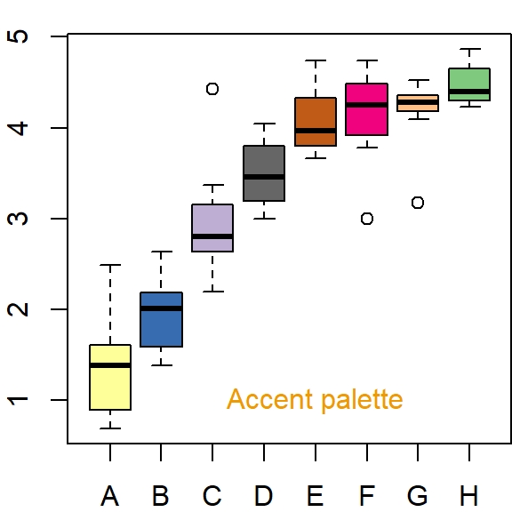

```r
boxplot(log(decrease) ~ treatment, data = OrchardSprays,
        col = OrchardSprays$treatment)
```

If you want to revert the palette back to the default, set the palette name to `"R4"`.

```r
palette("R4")
palette()
```

```
## [1] "black"   "#DF536B" "#61D04F" "#2297E6" "#28E2E5" "#CD0BBC" "#F5C710"
## [8] "gray62"
```

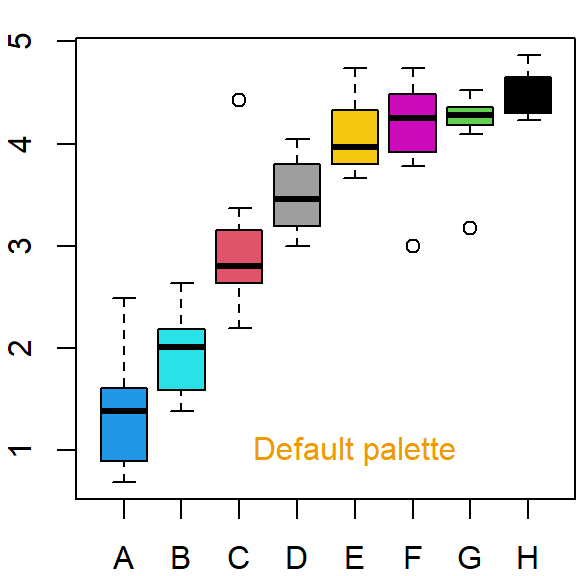

```r
boxplot(log(decrease) ~ treatment, data = OrchardSprays,
        col = OrchardSprays$treatment)
```

If you want to replicate the default color palette available in R prior to version 4.1, set the palette name to `"R3"`.

```r
palette("R3")
palette()
```

```
## [1] "black"   "red"     "green3"  "blue"    "cyan"    "magenta" "yellow"
## [8] "gray"
```

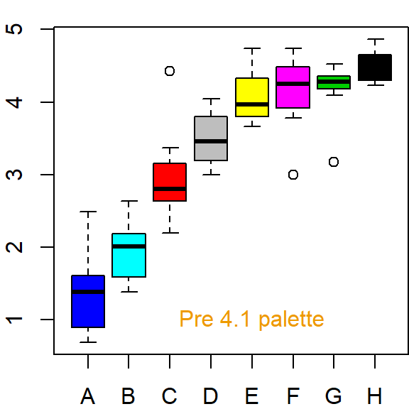

```r
boxplot(log(decrease) ~ treatment, data = OrchardSprays,
        col = OrchardSprays$treatment)
```

The palettes in R 4.1 vary in the number of color swatches. The following plot shows all colors available for each palette.

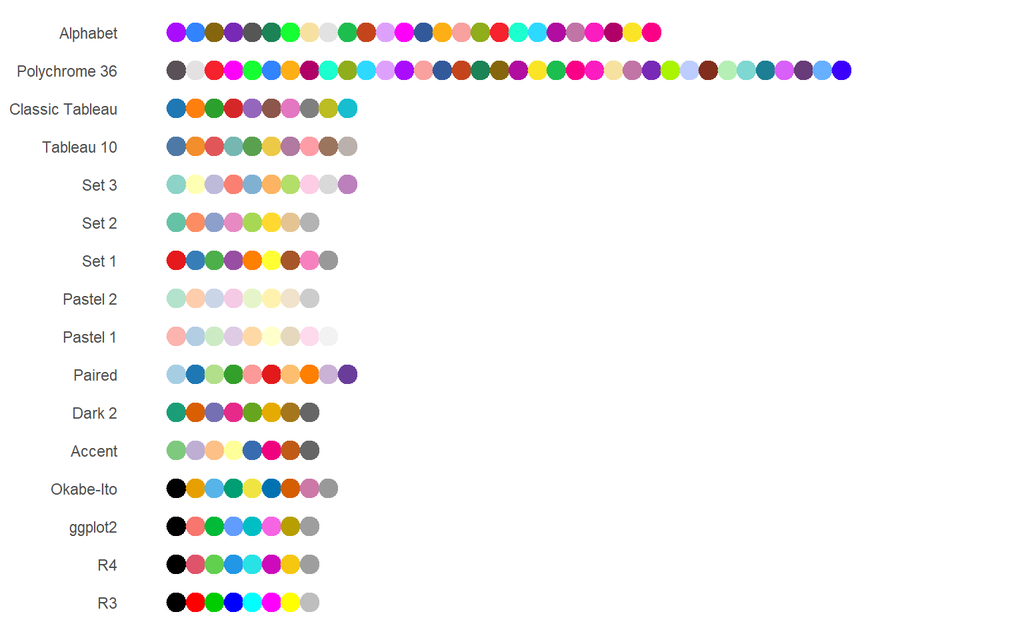

Manuel Gimond, 2021